# Introduction to Data Wrangling and Visualization with Python

## Kuo, Yao-Jen 郭耀仁

## Agenda

- About Me
- A Short Glimpse of a Data Science Project
- Data Wrangling with Python
- Data Visualization with Python

## About Me

https://yaojenkuo.io/00-about.slides.html#/2

## A Short Glimpse of a Data Science Project

## TL; DR

> Data science is a huge field, it invovles applications and tools like importing, tidying, transformation, visualization, modeling, and communication. Surrounding all these is programming.

Source: [R for Data Science](https://r4ds.had.co.nz/)

## A typical data science project is a pipeline looks like

[figure not shown]

Source: [R for Data Science](https://r4ds.had.co.nz/)

## How does Python tackle all these applications?

[figure not shown]

Source: https://giphy.com/

## PEP 206(Python Enhancement Proposals 206): [Python Advanced Library](https://www.python.org/dev/peps/pep-0206/) plays the key role

## The Python source distribution has long maintained the philosophy of "batteries included": having a rich and versatile standard library which is immediately available

- `random`
- `datetime`
- `json`
- ...etc.

## However, the standard library modules aren't always the best choices for a specific application

## A list of third-party modules that make Python the go-to choice for most of the data science teams

- `requests`
- `numpy`
- `pandas`
- `matplotlib`
- `scikit-learn`
- `scipy`
- `tensorflow`
- `pytorch`
- `flask`
- `dash`
- ...etc.

## Import: This typically means that we take data stored in a file, database, or web API, and load it into a data structure in Python

- `csv`
- `json`
- `numpy`
- `pandas`
- `requests`
- `beautifulsoup4`
- `lxml`
- `sqlite3`

## Tidy: Storing data in a consistent form that matches the semantics of the dataset. Tidy data is important because the more consistent the easier for us to get it into the right form for different functions

- `numpy`
- `pandas`
- Functional programming techniques

## Transform: For instance narrowing in on observations of interest, creating new variables that are functions of existing variables, and calculating a set of summary statistics

- `numpy`
- `pandas`
- Functional programming techniques

## Together, tidying and transforming are called WRANGLING!

[figure not shown]

Source: https://giphy.com/

## Visualize: A fundamental human activity. A good visualisation will show you things that you did not expect, or raise new questions about the data.

- `pandas`
- `matplotlib`
- `seaborn`

## Model: Once we've made questions sufficiently precise, we can use a mathematical or computational tool to answer them

- `scikit-learn`
- `scipy`
- `tensorflow`
- `pytorch`

## Communicate: It doesn’t matter how well our project is unless we can communicate the results to others

- `jupyter`
- `dash`

## Communication matters

> It should be possible to explain the laws of physics to a barmaid.

Source: [Einstein: His Life and Times](https://www.amazon.com/Einstein-Times-Ronald-W-Clark/dp/0061351849)

## Data Wrangling with Python

## TL; DR

> We brief the what and why on pandas and a quickstart of common DataFrame operations with 91APP dataset.

## What is pandas

> Flexible and powerful data analysis / manipulation library for Python, providing labeled data structures similar to R data.frame objects, statistical functions, and much more.

Source: https://github.com/pandas-dev/pandas

## Why pandas

Python has always been a popular language for web scraping, however there is a weak spot in its analysis capability. Python used to switch to a more data-centric language like R or Matlab during the analysis stage.

## Quick question: how does panda relate to data?

[figure not shown]

Source: https://giphy.com/

## Turns out it has nothing to do with panda...

## pandas refers to three primary class customed by its author [Wes McKinney](https://wesmckinney.com/)

- **Pan**el
- **Da**taFrame
- **S**eries

## Data analysts mainly deal with `Index`, `ndarray`, `Series`, `DataFrame`

- `DataFrame`
  - `Series`
    - `Index`
    - `ndarray`

## Libraries we need for the following demo

```python
import numpy as np
import pandas as pd
import seaborn as sns
import matplotlib.pyplot as plt
import sqlite3
```

## Combining an `Index` and a `ndarray` can form a `Series`

```python
movie_index = pd.Index(['The Avengers', 'Avengers: Age of Ultron', 'Avengers: Infinity War', 'Avengers: Endgame'])
movie_ratings = np.array([8, 7.3, 8.5, 8.4])
print(type(movie_index))
print(type(movie_ratings))
```

```
<class 'pandas.core.indexes.base.Index'>
<class 'numpy.ndarray'>
```

```python
rating_series = pd.Series(movie_ratings, movie_index)
print(type(rating_series))
print(rating_series)
```

```
<class 'pandas.core.series.Series'>
The Avengers               8.0
Avengers: Age of Ultron    7.3
Avengers: Infinity War     8.5
Avengers: Endgame          8.4
dtype: float64
```

## And vice versa...

```python
rating_series = pd.Series([8, 7.3, 8.5, 8.4], ['The Avengers', 'Avengers: Age of Ultron', 'Avengers: Infinity War', 'Avengers: Endgame'])
print(type(rating_series))
print(type(rating_series.index))
print(type(rating_series.values))
```

```
<class 'pandas.core.series.Series'>
<class 'pandas.core.indexes.base.Index'>
<class 'numpy.ndarray'>
```

## Combining multiple `Series` with the same `Index` can form a `DataFrame`

```python
release_year_series = pd.Series([2012, 2015, 2018, 2019], ['The Avengers', 'Avengers: Age of Ultron', 'Avengers: Infinity War', 'Avengers: Endgame'])
movie_df = pd.DataFrame()
movie_df['rating'] = rating_series
movie_df['release_year'] = release_year_series
print(type(movie_df))
movie_df
```

```
<class 'pandas.core.frame.DataFrame'>
```

|  | rating | release_year |
| --- | --- | --- |
| The Avengers | 8.0 | 2012 |
| Avengers: Age of Ultron | 7.3 | 2015 |
| Avengers: Infinity War | 8.5 | 2018 |
| Avengers: Endgame | 8.4 | 2019 |

## And vice versa...

```python
print(type(movie_df['rating']))
print(type(movie_df['rating'].index))
```

```
<class 'pandas.core.series.Series'>
<class 'pandas.core.indexes.base.Index'>
```

## Main pandas functionalities which data analysts rely on are

- Import
- Wrangling(Tidy + Transform)
- Visualize

## pandas has massive functions importing tabular data

- Flat text file
- Database table
- Spreadsheet
- Array of JSONs
- ...etc.

Source: https://pandas.pydata.org/pandas-docs/stable/user_guide/io.html

## Flat text files: 91APP Dataset

- BehaviorDataForNTU.csv
- MemberDataForNTU.csv
- OrderDataForNTU.csv
- OrderSlaveDataForNTU.txt

Source: NTU資料分析與決策社

## Check file encoding before importing

- Use text editor [Notepad++](https://notepad-plus-plus.org/downloads/)
- Use command line `file --mime-encoding <filename>`
  - macOS/Linux: Terminal
  - Windows: [Git Bash](https://gitforwindows.org/)

```python
!file --mime-encoding *.csv
!file --mime-encoding *.txt
```

```
BehaviorDataForNTU.csv: utf-8
MemberDataForNTU.csv:   us-ascii
OrderDataForNTU.csv:    us-ascii
OrderSlaveDataForNTU.txt: us-ascii
```

## Importing using pandas `read_csv` functions

```python
# for example
order_slave = pd.read_csv('OrderSlaveDataForNTU.txt')
```

```python
order_slave.shape
```

```
(1159830, 15)
```

```python
order_slave.dtypes
```

```
UUID                    object
TransactionNum          object
TradesDateTime          object
ChannelType             object
ChannelDetail           object
PaymentType             object
ShippingType            object
OuterProductSkuCode     object
ProductSkuCode         float64
SalePageCode           float64
Qty                      int64
TotalSalesAmount         int64
TotalPrice               int64
TotalDiscount            int64
Status                  object
dtype: object
```

## Assigning data types if there is a warning message

```python
dtypes = {
    'PaymentType': 'str',
    'ShippingType': 'str'
}
order_slave = pd.read_csv('OrderSlaveDataForNTU.txt', dtype=dtypes)
```

## Why `DtypeWarning`?

Pandas is built on numpy, numpy records missing values with `np.NaN` which is a `float` type.

```python
print(type(np.NaN))
```

```
<class 'float'>
```

## Importing other files as well

```python
dtypes = {
    'CategoryId': 'str',
    'SearchKeyWord': 'str',
    'TransactionNum': 'str'
}
behavior = pd.read_csv('BehaviorDataForNTU.csv', dtype=dtypes)
member = pd.read_csv('MemberDataForNTU.csv')
order_main = pd.read_csv('OrderDataForNTU.csv')
```

## Using `shape` attribute to check layout

```python
print(behavior.shape)
print(member.shape)
print(order_main.shape)
print(order_slave.shape)
```

```
(15081048, 15)
(159835, 11)
(508083, 18)
(1159830, 15)
```

## Using `head` method for a peek

```python
behavior.head()
```

|  | VisitorId | OperationSystem | SessionNumber | TrafficSourceCategory | HitDateTime | BehaviorType | SourceType | OnlineMemberId | CategoryId | SearchKeyWord | TransactionNum | ProductPrice | ProductQuantity | ProductId | TransactionRevenue |
| --- | --- | --- | --- | --- | --- | --- | --- | --- | --- | --- | --- | --- | --- | --- | --- |
| 0 | d960a83d-f413-4659-813c-6cd1610a1292 | iOS | 3.0 | Direct | 2018-05-16 23:14:31.500 | Purchase | APP | 2783844908 | NaN | NaN | 1e90QjPFvmpWFROtMl0nBA9w3dD= | 1380.0 | 1.0 | 4298287.0 | 4330.0 |
| 1 | 43a28e13-df38-45a3-6038-f676b0ac61ba | Windows | 1.0 | Direct | 2018-12-27 20:52:30.428 | Purchase | WEB | 3583134573 | NaN | NaN | RRL2Ah/8qPfZDdARqQ/cT2gSO0L= | 1447.0 | 1.0 | 4899494.0 | 4620.0 |
| 2 | cae70e93-fec0-4c52-38a5-da5c0c77e976 | Android | 1.0 | Direct | 2018-06-07 06:17:15.701 | Purchase | WEB | 3384591959 | NaN | NaN | wdLh1oFx6lNjV1ENQtBVFglDVcD= | 1280.0 | 1.0 | 4305841.0 | 2460.0 |
| 3 | e903d188-cf9d-423a-b058-93d0c882ba2d | Android | 1.0 | Facebook | 2018-05-09 12:06:41.670 | Purchase | WEB | 47808784R2 | NaN | NaN | csoMr0O2AdKUG2M3k9m5HjwymtZ= | 1280.0 | 1.0 | 4259098.0 | 2860.0 |
| 4 | 05d9c7be-ad65-48d6-17c7-2d2ddb14ab37 | Android | 1.0 | Facebook | 2018-03-12 07:34:54.457 | Purchase | WEB | 3483273161 | NaN | NaN | A75CPoWttFCvO3/M5NQxH51LLtb= | 690.0 | 1.0 | 4167807.0 | 2170.0 |

```python
member.head()
```

|  | UUID | OnlineMemberId | RegisterSourceTypeDef | RegisterDate | Gender | Birthday | IsAppInstalled | IsEnableEmail | IsEnableShortMessage | IsEnablePushNotification | MemberCardLevel |
| --- | --- | --- | --- | --- | --- | --- | --- | --- | --- | --- | --- |
| 0 | X03665298 | NaN | Store | 2011/12/4 | Female | 1965/1/10 | False | True | True | True | 10 |
| 1 | T04434917 | NaN | Store | 2011/12/19 | Female | 1900/1/1 | False | True | True | True | 10 |
| 2 | T03441135 | NaN | Store | 2011/12/19 | Female | 1983/1/18 | False | True | True | True | 20 |
| 3 | W03686173 | NaN | Store | 2011/12/28 | Female | 1980/1/1 | False | True | True | True | 10 |
| 4 | W03441148 | NaN | Store | 2011/12/19 | Female | 1900/1/1 | False | True | True | True | 10 |

```python
order_main.head()
```

|  | UUID | TransactionNum | TradesDate | ChannelType | ChannelDetail | PaymentType | ShippingType | BeforeMemberTierLevel | AfterMemberTierLevel | TsCount | Qty | TotalSalesAmount | TotalPrice | TotalDiscount | TotalPromotionDiscount | TotalCouponDiscount | TotalLoyaltyDiscount | Status |
| --- | --- | --- | --- | --- | --- | --- | --- | --- | --- | --- | --- | --- | --- | --- | --- | --- | --- | --- |
| 0 | U2131156 | 84GbV1FZLS+u1nu1FgX7AxmHsab= | 2018/7/10 | Pos | A039 | Cash | Store | 0 | 0 | 1 | 1 | 2380 | 2380 | 0 | 0 | 0 | 0 | Finish |
| 1 | V02663974 | g3sJev+nMFHCc7J+3MIkXaeA3wV= | 2018/7/3 | Pos | A042 | Cash | Store | 0 | 0 | 1 | 1 | 390 | 390 | 0 | 0 | 0 | 0 | Finish |
| 2 | R03555577 | jajyDU5zj3+0NFjBDzIPiijAdDD= | 2018/7/4 | Pos | A050 | Cash | Store | 0 | 0 | 1 | 1 | 1480 | 1480 | 0 | 0 | 0 | 0 | Finish |
| 3 | O07191104 | W5qdVNdgnsWEx8a7ikzHw/KbGI6= | 2018/7/7 | Pos | A051 | Cash | Store | 0 | 0 | 1 | 1 | 1380 | 1380 | 0 | 0 | 0 | 0 | Finish |
| 4 | U99462295 | zVBGf/pLjTKHQFQUEQ5zUTvS8Yp= | 2018/7/8 | Pos | A054 | Cash | Store | 0 | 0 | 1 | 1 | 1280 | 1280 | 0 | 0 | 0 | 0 | Finish |

```python
order_slave.head()
```

|  | UUID | TransactionNum | TradesDateTime | ChannelType | ChannelDetail | PaymentType | ShippingType | OuterProductSkuCode | ProductSkuCode | SalePageCode | Qty | TotalSalesAmount | TotalPrice | TotalDiscount | Status |
| --- | --- | --- | --- | --- | --- | --- | --- | --- | --- | --- | --- | --- | --- | --- | --- |
| 0 | T04536285 | o2MqkS6y1AR0o4shLXAyZKye9Ct= | 2016-04-01 18:07:20 | Pos | C030 | NaN | NaN | 746140050903 | NaN | NaN | 1 | 0 | 0 | 0 | Finish |
| 1 | T04536285 | o2MqkS6y1AR0o4shLXAyZKye9Ct= | 2016-04-01 18:07:20 | Pos | C030 | NaN | NaN | 746140050902 | NaN | NaN | -1 | 0 | 0 | 0 | Return |
| 2 | P1674651 | gfsCr+82rsF9Qm1sU5KtXiKwlnN= | 2016-04-03 16:10:27 | Pos | A057 | NaN | NaN | 935200275002 | NaN | NaN | 1 | 0 | 0 | 0 | Finish |
| 3 | P1674651 | gfsCr+82rsF9Qm1sU5KtXiKwlnN= | 2016-04-03 16:10:27 | Pos | A057 | NaN | NaN | 935200275001 | NaN | NaN | -1 | 0 | 0 | 0 | Return |
| 4 | N00537019 | wEHcPVo+2/Jzi1Lj5RfCeG5JD+6= | 2016-04-03 18:23:45 | Pos | A057 | NaN | NaN | 116110010002 | NaN | NaN | -1 | 0 | 0 | 0 | Return |

## It is also recommended storing data in a database, especially for large dataset like `BehaviorDataForNTU.csv`

ntu_dac_91APP.db

```python
conn = sqlite3.connect('ntu_dac_91APP.db')
query_str = """
SELECT *
    FROM order_slave
    LIMIT 5;
"""
pd.read_sql(query_str, conn)
```

|  | UUID | TransactionNum | TradesDateTime | ChannelType | ChannelDetail | PaymentType | ShippingType | OuterProductSkuCode | ProductSkuCode | SalePageCode | Qty | TotalSalesAmount | TotalPrice | TotalDiscount | Status |
| --- | --- | --- | --- | --- | --- | --- | --- | --- | --- | --- | --- | --- | --- | --- | --- |
| 0 | T04536285 | o2MqkS6y1AR0o4shLXAyZKye9Ct= | 2016-04-01 18:07:20 | Pos | C030 | None | None | 7.461401e+11 | None | None | 1 | 0 | 0 | 0 | Finish |
| 1 | T04536285 | o2MqkS6y1AR0o4shLXAyZKye9Ct= | 2016-04-01 18:07:20 | Pos | C030 | None | None | 7.461401e+11 | None | None | -1 | 0 | 0 | 0 | Return |
| 2 | P1674651 | gfsCr+82rsF9Qm1sU5KtXiKwlnN= | 2016-04-03 16:10:27 | Pos | A057 | None | None | 9.352003e+11 | None | None | 1 | 0 | 0 | 0 | Finish |
| 3 | P1674651 | gfsCr+82rsF9Qm1sU5KtXiKwlnN= | 2016-04-03 16:10:27 | Pos | A057 | None | None | 9.352003e+11 | None | None | -1 | 0 | 0 | 0 | Return |
| 4 | N00537019 | wEHcPVo+2/Jzi1Lj5RfCeG5JD+6= | 2016-04-03 18:23:45 | Pos | A057 | None | None | 1.161100e+11 | None | None | -1 | 0 | 0 | 0 | Return |

## Once we've done importing dataset, there are some common attributes/methods to examine a `DataFrame` object

- `shape`
- `info()`
- `head()`/`tail()`
- `describe()`

```python
order_main.info()
```

```
<class 'pandas.core.frame.DataFrame'>
RangeIndex: 508083 entries, 0 to 508082
Data columns (total 18 columns):
UUID                      508083 non-null object
TransactionNum            508083 non-null object
TradesDate                508083 non-null object
ChannelType               508083 non-null object
ChannelDetail             508083 non-null object
PaymentType               508083 non-null object
ShippingType              508083 non-null object
BeforeMemberTierLevel     508083 non-null int64
AfterMemberTierLevel      508083 non-null int64
TsCount                   508083 non-null int64
Qty                       508083 non-null int64
TotalSalesAmount          508083 non-null int64
TotalPrice                508083 non-null int64
TotalDiscount             508083 non-null int64
TotalPromotionDiscount    508083 non-null int64
TotalCouponDiscount       508083 non-null int64
TotalLoyaltyDiscount      508083 non-null int64
Status                    508083 non-null object
dtypes: int64(10), object(8)
memory usage: 69.8+ MB
```

```python
order_main.describe()
```

|  | BeforeMemberTierLevel | AfterMemberTierLevel | TsCount | Qty | TotalSalesAmount | TotalPrice | TotalDiscount | TotalPromotionDiscount | TotalCouponDiscount | TotalLoyaltyDiscount |
| --- | --- | --- | --- | --- | --- | --- | --- | --- | --- | --- |
| count | 508083.0 | 508083.0 | 508083.000000 | 508083.000000 | 508083.000000 | 508083.000000 | 508083.000000 | 508083.000000 | 508083.000000 | 508083.0 |
| mean | 0.0 | 0.0 | 2.247958 | 1.898645 | 2642.526402 | 2693.586961 | -51.060559 | -3.998362 | -47.062197 | 0.0 |
| std | 0.0 | 0.0 | 1.959992 | 2.300044 | 3488.535635 | 3502.082785 | 178.671054 | 61.354120 | 168.924130 | 0.0 |
| min | 0.0 | 0.0 | 1.000000 | -36.000000 | -53790.000000 | -53790.000000 | -9100.000000 | -9100.000000 | -5000.000000 | 0.0 |
| 25% | 0.0 | 0.0 | 1.000000 | 1.000000 | 1280.000000 | 1280.000000 | 0.000000 | 0.000000 | 0.000000 | 0.0 |
| 50% | 0.0 | 0.0 | 2.000000 | 1.000000 | 1980.000000 | 2070.000000 | 0.000000 | 0.000000 | 0.000000 | 0.0 |
| 75% | 0.0 | 0.0 | 3.000000 | 3.000000 | 3460.000000 | 3560.000000 | 0.000000 | 0.000000 | 0.000000 | 0.0 |
| max | 0.0 | 0.0 | 162.000000 | 162.000000 | 255960.000000 | 255960.000000 | 1000.000000 | 0.000000 | 1000.000000 | 0.0 |

## Once we've done importing and examination, we can move on to general `DataFrame` operations

- Selecting
- Filtering
- Subsetting
- Indexing
- Sorting
- Deriving
- Summarizing
- Summarizing and Grouping

## Selecting columns from `DataFrame`

```python
cols_to_select = ['RegisterDate', 'Gender', 'Birthday']
member[cols_to_select]
```

|  | RegisterDate | Gender | Birthday |
| --- | --- | --- | --- |
| 0 | 2011/12/4 | Female | 1965/1/10 |
| 1 | 2011/12/19 | Female | 1900/1/1 |
| 2 | 2011/12/19 | Female | 1983/1/18 |
| 3 | 2011/12/28 | Female | 1980/1/1 |
| 4 | 2011/12/19 | Female | 1900/1/1 |
| ... | ... | ... | ... |
| 159830 | 2018/12/19 | Female | 1966/1/23 |
| 159831 | 2018/12/18 | Female | 1963/12/18 |
| 159832 | 2018/12/16 | Female | 1966/11/7 |
| 159833 | 2018/12/25 | Female | 1986/6/15 |
| 159834 | 2018/12/29 | Female | 1959/3/26 |

159835 rows × 3 columns

## Filtering rows from `DataFrame`

```python
rows_to_select = member['Gender'] == 'Male'
member[rows_to_select]
```

|  | UUID | OnlineMemberId | RegisterSourceTypeDef | RegisterDate | Gender | Birthday | IsAppInstalled | IsEnableEmail | IsEnableShortMessage | IsEnablePushNotification | MemberCardLevel |
| --- | --- | --- | --- | --- | --- | --- | --- | --- | --- | --- | --- |
| 53 | S04520222 | NaN | Store | 2011/12/25 | Male | 1982/4/11 | False | True | True | True | 10 |
| 108 | U03583772 | NaN | Store | 2012/1/1 | Male | 1981/10/16 | False | True | True | True | 10 |
| 109 | R03583770 | NaN | Store | 2011/12/18 | Male | 1982/10/14 | False | True | True | True | 10 |
| 117 | W04520226 | NaN | Store | 2011/12/25 | Male | 1980/11/16 | False | True | True | True | 20 |
| 120 | P03583767 | NaN | Store | 2011/12/10 | Male | 1984/11/23 | False | True | True | True | 10 |
| ... | ... | ... | ... | ... | ... | ... | ... | ... | ... | ... | ... |
| 159198 | T96759858 | 45844100P0 | LocationWizard | 2018/12/27 | Male | 1974/3/29 | True | True | True | True | 10 |
| 159578 | T96399026 | 3885746594 | LocationWizard | 2018/12/11 | Male | 1976/9/25 | True | True | True | True | 10 |
| 159655 | S96478806 | 3184873530 | LocationWizard | 2018/12/16 | Male | 1992/12/16 | True | False | False | False | 10 |
| 159739 | O96696810 | 3185458431 | LocationWizard | 2018/12/22 | Male | 1971/11/8 | False | True | True | True | 10 |
| 159742 | N96481013 | 3285768749 | LocationWizard | 2018/12/13 | Male | 1960/8/20 | True | True | True | True | 10 |

1927 rows × 11 columns

## Subsetting columns and rows simultaneously from `DataFrame`

```python
cols_to_select = ['RegisterDate', 'Gender', 'Birthday']
rows_to_select = member['Gender'] == 'Male'
member[rows_to_select][cols_to_select]
```

|  | RegisterDate | Gender | Birthday |
| --- | --- | --- | --- |
| 53 | 2011/12/25 | Male | 1982/4/11 |
| 108 | 2012/1/1 | Male | 1981/10/16 |
| 109 | 2011/12/18 | Male | 1982/10/14 |
| 117 | 2011/12/25 | Male | 1980/11/16 |
| 120 | 2011/12/10 | Male | 1984/11/23 |
| ... | ... | ... | ... |
| 159198 | 2018/12/27 | Male | 1974/3/29 |
| 159578 | 2018/12/11 | Male | 1976/9/25 |
| 159655 | 2018/12/16 | Male | 1992/12/16 |
| 159739 | 2018/12/22 | Male | 1971/11/8 |
| 159742 | 2018/12/13 | Male | 1960/8/20 |

1927 rows × 3 columns

## Indexing `DataFrame`

- `loc[]`: indexing with `Index`
- `iloc[]`: indexing with absolute positions

```python
male_members = member[rows_to_select]
male_members.loc[[53, 108, 109, 117, 120]]
```

|  | UUID | OnlineMemberId | RegisterSourceTypeDef | RegisterDate | Gender | Birthday | IsAppInstalled | IsEnableEmail | IsEnableShortMessage | IsEnablePushNotification | MemberCardLevel |
| --- | --- | --- | --- | --- | --- | --- | --- | --- | --- | --- | --- |
| 53 | S04520222 | NaN | Store | 2011/12/25 | Male | 1982/4/11 | False | True | True | True | 10 |
| 108 | U03583772 | NaN | Store | 2012/1/1 | Male | 1981/10/16 | False | True | True | True | 10 |
| 109 | R03583770 | NaN | Store | 2011/12/18 | Male | 1982/10/14 | False | True | True | True | 10 |
| 117 | W04520226 | NaN | Store | 2011/12/25 | Male | 1980/11/16 | False | True | True | True | 20 |
| 120 | P03583767 | NaN | Store | 2011/12/10 | Male | 1984/11/23 | False | True | True | True | 10 |

```python
male_members = member[rows_to_select]
male_members.iloc[[0, 1, 2, 3, 4]]
```

|  | UUID | OnlineMemberId | RegisterSourceTypeDef | RegisterDate | Gender | Birthday | IsAppInstalled | IsEnableEmail | IsEnableShortMessage | IsEnablePushNotification | MemberCardLevel |
| --- | --- | --- | --- | --- | --- | --- | --- | --- | --- | --- | --- |
| 53 | S04520222 | NaN | Store | 2011/12/25 | Male | 1982/4/11 | False | True | True | True | 10 |
| 108 | U03583772 | NaN | Store | 2012/1/1 | Male | 1981/10/16 | False | True | True | True | 10 |
| 109 | R03583770 | NaN | Store | 2011/12/18 | Male | 1982/10/14 | False | True | True | True | 10 |
| 117 | W04520226 | NaN | Store | 2011/12/25 | Male | 1980/11/16 | False | True | True | True | 20 |
| 120 | P03583767 | NaN | Store | 2011/12/10 | Male | 1984/11/23 | False | True | True | True | 10 |

## Sorting `DataFrame`

- `sort_values` method: sorting with a specific column
- `sort_index` method: sorting with the `Index` of `DataFrame`

```python
order_main.sort_values('TotalSalesAmount')
```

|  | UUID | TransactionNum | TradesDate | ChannelType | ChannelDetail | PaymentType | ShippingType | BeforeMemberTierLevel | AfterMemberTierLevel | TsCount | Qty | TotalSalesAmount | TotalPrice | TotalDiscount | TotalPromotionDiscount | TotalCouponDiscount | TotalLoyaltyDiscount | Status |
| --- | --- | --- | --- | --- | --- | --- | --- | --- | --- | --- | --- | --- | --- | --- | --- | --- | --- | --- |
| 485076 | X93677453 | sVy7Na3OtozUpbF36AULY2AtQHN= | 2018/11/15 | Pos | C040 | Cash | Store | 0 | 0 | 21 | -21 | -53790 | -53790 | 0 | 0 | 0 | 0 | Return |
| 319578 | W07477115 | LygZlpowSkpJ75b+yz8kh2FSj5H= | 2018/10/20 | Pos | A062 | Cash | Store | 0 | 0 | 17 | -17 | -53480 | -53480 | 0 | 0 | 0 | 0 | Return |
| 391437 | W05026959 | Nwtrv1T4K2fMSDhUyEEwICixRhN= | 2018/1/27 | Pos | C016 | Cash | Store | 0 | 0 | 2 | -2 | -48600 | -48600 | 0 | 0 | 0 | 0 | Return |
| 26575 | Q04238600 | aIt3Om1iHgkaEYIyW3PqppC+6Oj= | 2018/12/25 | Pos | A040 | Cash | Store | 0 | 0 | 7 | -7 | -45080 | -45080 | 0 | 0 | 0 | 0 | Return |
| 467183 | X94626005 | 0IPFjgAPUpaMKon2xaa13Wojcw6= | 2019/1/14 | Pos | A062 | Cash | Store | 0 | 0 | 12 | -12 | -39590 | -39590 | 0 | 0 | 0 | 0 | Return |
| ... | ... | ... | ... | ... | ... | ... | ... | ... | ... | ... | ... | ... | ... | ... | ... | ... | ... | ... |
| 467167 | W09391463 | jWG1/FVzp3Mxf0q4QtcXgbNV4rb= | 2019/1/3 | Pos | B055 | Cash | Store | 0 | 0 | 27 | 27 | 93160 | 93160 | 0 | 0 | 0 | 0 | Finish |
| 467081 | W7108275 | JlNXzMm8L4rju/V9iLB0WYYlb76= | 2019/1/29 | Pos | A015 | Cash | Store | 0 | 0 | 14 | 14 | 99920 | 99920 | 0 | 0 | 0 | 0 | Finish |
| 485054 | W05580065 | OvWmBv66dTEPr2UdrUkudTdyY+Z= | 2018/11/20 | Pos | A015 | Cash | Store | 0 | 0 | 19 | 19 | 118520 | 118520 | 0 | 0 | 0 | 0 | Finish |
| 391324 | W07813704 | LPKULMkVNK+ptb4he4ApOcvjV1R= | 2018/1/17 | Pos | A054 | Cash | Store | 0 | 0 | 85 | 85 | 159740 | 159840 | -100 | 0 | -100 | 0 | Finish |
| 413632 | R04234145 | zK6XGNghLYS3ZuQloS4ocxEXeW8= | 2019/4/14 | Pos | C019 | Cash | Store | 0 | 0 | 162 | 162 | 255960 | 255960 | 0 | 0 | 0 | 0 | Finish |

508083 rows × 18 columns

```python
male_members.sort_index(ascending=False)
```

|  | UUID | OnlineMemberId | RegisterSourceTypeDef | RegisterDate | Gender | Birthday | IsAppInstalled | IsEnableEmail | IsEnableShortMessage | IsEnablePushNotification | MemberCardLevel |
| --- | --- | --- | --- | --- | --- | --- | --- | --- | --- | --- | --- |
| 159742 | N96481013 | 3285768749 | LocationWizard | 2018/12/13 | Male | 1960/8/20 | True | True | True | True | 10 |
| 159739 | O96696810 | 3185458431 | LocationWizard | 2018/12/22 | Male | 1971/11/8 | False | True | True | True | 10 |
| 159655 | S96478806 | 3184873530 | LocationWizard | 2018/12/16 | Male | 1992/12/16 | True | False | False | False | 10 |
| 159578 | T96399026 | 3885746594 | LocationWizard | 2018/12/11 | Male | 1976/9/25 | True | True | True | True | 10 |
| 159198 | T96759858 | 45844100P0 | LocationWizard | 2018/12/27 | Male | 1974/3/29 | True | True | True | True | 10 |
| ... | ... | ... | ... | ... | ... | ... | ... | ... | ... | ... | ... |
| 120 | P03583767 | NaN | Store | 2011/12/10 | Male | 1984/11/23 | False | True | True | True | 10 |
| 117 | W04520226 | NaN | Store | 2011/12/25 | Male | 1980/11/16 | False | True | True | True | 20 |
| 109 | R03583770 | NaN | Store | 2011/12/18 | Male | 1982/10/14 | False | True | True | True | 10 |
| 108 | U03583772 | NaN | Store | 2012/1/1 | Male | 1981/10/16 | False | True | True | True | 10 |
| 53 | S04520222 | NaN | Store | 2011/12/25 | Male | 1982/4/11 | False | True | True | True | 10 |

1927 rows × 11 columns

## Deriving new variables from `DataFrame`

- `map` with a `dict`
- `map` with a function(or a lambda expression)

```python
member['RegisterSourceTypeDef'].unique()
```

```
array(['Store', 'iOSApp', 'LocationWizard', 'Web', 'AndroidApp', nan],
      dtype=object)
```

```python
register_source_dict = {
    'Store': 'Non mobile app',
    'LocationWizard': 'Non mobile app',
    'Web': 'Non mobile app',
    'AndroidApp': 'Mobile app',
    'iOSApp': 'Mobile app',
    np.NaN: 'Non mobile app'
}
member['RegisterSourceTypeDef'].map(register_source_dict).value_counts()
```

```
Non mobile app    129817
Mobile app         30018
Name: RegisterSourceTypeDef, dtype: int64
```

```python
def register_source_func(x):
    if x in ['AndroidApp', 'iOSApp']:
        return 'Mobile app'
    else:
        return 'Non mobile app'
member['RegisterSourceTypeDef'].map(register_source_func).value_counts()
```

```
Non mobile app    129817
Mobile app         30018
Name: RegisterSourceTypeDef, dtype: int64
```

## Summarizing `DataFrame` with built-in methods

```python
order_main['TotalSalesAmount'].sum()
```

```
1342622742
```

## Summarizing and grouping `DataFrame` with built-in methods

```python
order_main.groupby('PaymentType')['TotalSalesAmount'].sum()
```

```
PaymentType
ATM                    91308
Cash              1093109830
CreditCardOnce      80850669
Family              75396620
LinePay              6214910
SevenEleven         86959405
Name: TotalSalesAmount, dtype: int64
```

## Once general operations are done, we can move on to advanced `DataFrame` operations

- Text to `datetime` type
- Dealing with missing values
- Merging(joining) dataframes

## Text to `datetime` type

```python
print(behavior['HitDateTime'][:100])
```

```
0     2018-05-16 23:14:31.500
1     2018-12-27 20:52:30.428
2     2018-06-07 06:17:15.701
3     2018-05-09 12:06:41.670
4     2018-03-12 07:34:54.457
               ...
95    2018-11-27 20:07:52.028
96    2018-07-16 23:21:10.482
97    2018-07-17 23:15:20.457
98    2018-07-17 21:44:05.717
99    2018-06-12 08:27:47.882
Name: HitDateTime, Length: 100, dtype: object
```

```python
print(pd.to_datetime(behavior['HitDateTime'][:100]))
```

```
0    2018-05-16 23:14:31.500
1    2018-12-27 20:52:30.428
2    2018-06-07 06:17:15.701
3    2018-05-09 12:06:41.670
4    2018-03-12 07:34:54.457
               ...
95   2018-11-27 20:07:52.028
96   2018-07-16 23:21:10.482
97   2018-07-17 23:15:20.457
98   2018-07-17 21:44:05.717
99   2018-06-12 08:27:47.882
Name: HitDateTime, Length: 100, dtype: datetime64[ns]
```

```python
print(member['RegisterDate'])
```

```
0          2011/12/4
1         2011/12/19
2         2011/12/19
3         2011/12/28
4         2011/12/19
             ...
159830    2018/12/19
159831    2018/12/18
159832    2018/12/16
159833    2018/12/25
159834    2018/12/29
Name: RegisterDate, Length: 159835, dtype: object
```

```python
print(pd.to_datetime(member['RegisterDate']))
```

```
0        2011-12-04
1        2011-12-19
2        2011-12-19
3        2011-12-28
4        2011-12-19
            ...
159830   2018-12-19
159831   2018-12-18
159832   2018-12-16
159833   2018-12-25
159834   2018-12-29
Name: RegisterDate, Length: 159835, dtype: datetime64[ns]
```

## Dealing with missing values

- Using `isnull` and `notnull` to check if `np.NaN` exists
- Using `dropna` to drop rows with `np.NaN`
- Using `fillna` to fill `np.NaN` with specific values

```python
print(member.shape[0])
print("===")
print(member['RegisterSourceTypeDef'].isnull().sum())
print(member['RegisterSourceTypeDef'].notnull().sum())
print("===")
print(member.dropna().shape[0])
print("===")
print(member['RegisterSourceTypeDef'].fillna('Unknown').isnull().sum())
print(member['RegisterSourceTypeDef'].fillna('Unknown').notnull().sum())
```

```
159835
===
14
159821
===
94067
===
0
159835
```

## Merging(joining) dataframes

- `merge` function on column
- `join` method on index

```python
# Retrieve the order_main of max TotalSalesAmount
max_ttl_sales_amt = order_main['TotalSalesAmount'].max()
max_order_main = order_main[order_main.TotalSalesAmount == max_ttl_sales_amt]
max_order_main
```

|  | UUID | TransactionNum | TradesDate | ChannelType | ChannelDetail | PaymentType | ShippingType | BeforeMemberTierLevel | AfterMemberTierLevel | TsCount | Qty | TotalSalesAmount | TotalPrice | TotalDiscount | TotalPromotionDiscount | TotalCouponDiscount | TotalLoyaltyDiscount | Status |
| --- | --- | --- | --- | --- | --- | --- | --- | --- | --- | --- | --- | --- | --- | --- | --- | --- | --- | --- |
| 413632 | R04234145 | zK6XGNghLYS3ZuQloS4ocxEXeW8= | 2019/4/14 | Pos | C019 | Cash | Store | 0 | 0 | 162 | 162 | 255960 | 255960 | 0 | 0 | 0 | 0 | Finish |

```python
# Retrieve the order_slave of max TotalSalesAmount
max_transaction_num = max_order_main['TransactionNum'].values[0]
max_order_slave = order_slave[order_slave['TransactionNum'] == max_transaction_num]
max_order_slave
```

|  | UUID | TransactionNum | TradesDateTime | ChannelType | ChannelDetail | PaymentType | ShippingType | OuterProductSkuCode | ProductSkuCode | SalePageCode | Qty | TotalSalesAmount | TotalPrice | TotalDiscount | Status |
| --- | --- | --- | --- | --- | --- | --- | --- | --- | --- | --- | --- | --- | --- | --- | --- |
| 1087514 | R04234145 | zK6XGNghLYS3ZuQloS4ocxEXeW8= | 2019-04-14 17:58:33 | Pos | C019 | NaN | NaN | 509120990901 | NaN | NaN | 1 | 255960 | 255960 | 0 | Finish |
| 1087515 | R04234145 | zK6XGNghLYS3ZuQloS4ocxEXeW8= | 2019-04-14 17:58:33 | Pos | C019 | NaN | NaN | 509120990901 | NaN | NaN | 1 | 255960 | 255960 | 0 | Finish |
| 1087516 | R04234145 | zK6XGNghLYS3ZuQloS4ocxEXeW8= | 2019-04-14 17:58:33 | Pos | C019 | NaN | NaN | 509120990901 | NaN | NaN | 1 | 255960 | 255960 | 0 | Finish |
| 1087517 | R04234145 | zK6XGNghLYS3ZuQloS4ocxEXeW8= | 2019-04-14 17:58:33 | Pos | C019 | NaN | NaN | 509120990901 | NaN | NaN | 1 | 255960 | 255960 | 0 | Finish |
| 1087519 | R04234145 | zK6XGNghLYS3ZuQloS4ocxEXeW8= | 2019-04-14 17:58:33 | Pos | C019 | NaN | NaN | 509120990901 | NaN | NaN | 1 | 255960 | 255960 | 0 | Finish |
| ... | ... | ... | ... | ... | ... | ... | ... | ... | ... | ... | ... | ... | ... | ... | ... |
| 1087679 | R04234145 | zK6XGNghLYS3ZuQloS4ocxEXeW8= | 2019-04-14 17:58:33 | Pos | C019 | NaN | NaN | 509120990907 | NaN | NaN | 1 | 255960 | 255960 | 0 | Finish |
| 1087680 | R04234145 | zK6XGNghLYS3ZuQloS4ocxEXeW8= | 2019-04-14 17:58:33 | Pos | C019 | NaN | NaN | 509120990907 | NaN | NaN | 1 | 255960 | 255960 | 0 | Finish |
| 1087681 | R04234145 | zK6XGNghLYS3ZuQloS4ocxEXeW8= | 2019-04-14 17:58:33 | Pos | C019 | NaN | NaN | 509120990907 | NaN | NaN | 1 | 255960 | 255960 | 0 | Finish |
| 1087682 | R04234145 | zK6XGNghLYS3ZuQloS4ocxEXeW8= | 2019-04-14 17:58:33 | Pos | C019 | NaN | NaN | 509120990907 | NaN | NaN | 1 | 255960 | 255960 | 0 | Finish |
| 1087683 | R04234145 | zK6XGNghLYS3ZuQloS4ocxEXeW8= | 2019-04-14 17:58:33 | Pos | C019 | NaN | NaN | 509120990907 | NaN | NaN | 1 | 255960 | 255960 | 0 | Finish |

162 rows × 15 columns

## We can use either `UUID` or `TransactionNum` as our foreign keys

```python
pd.merge(max_order_slave, max_order_main, left_on='UUID', right_on='UUID', suffixes=('_slave', '_main'))
```

|  | UUID | TransactionNum_slave | TradesDateTime | ChannelType_slave | ChannelDetail_slave | PaymentType_slave | ShippingType_slave | OuterProductSkuCode | ProductSkuCode | SalePageCode | ... | AfterMemberTierLevel | TsCount | Qty_main | TotalSalesAmount_main | TotalPrice_main | TotalDiscount_main | TotalPromotionDiscount | TotalCouponDiscount | TotalLoyaltyDiscount | Status_main |
| --- | --- | --- | --- | --- | --- | --- | --- | --- | --- | --- | --- | --- | --- | --- | --- | --- | --- | --- | --- | --- | --- |
| 0 | R04234145 | zK6XGNghLYS3ZuQloS4ocxEXeW8= | 2019-04-14 17:58:33 | Pos | C019 | NaN | NaN | 509120990901 | NaN | NaN | ... | 0 | 162 | 162 | 255960 | 255960 | 0 | 0 | 0 | 0 | Finish |
| 1 | R04234145 | zK6XGNghLYS3ZuQloS4ocxEXeW8= | 2019-04-14 17:58:33 | Pos | C019 | NaN | NaN | 509120990901 | NaN | NaN | ... | 0 | 162 | 162 | 255960 | 255960 | 0 | 0 | 0 | 0 | Finish |
| 2 | R04234145 | zK6XGNghLYS3ZuQloS4ocxEXeW8= | 2019-04-14 17:58:33 | Pos | C019 | NaN | NaN | 509120990901 | NaN | NaN | ... | 0 | 162 | 162 | 255960 | 255960 | 0 | 0 | 0 | 0 | Finish |
| 3 | R04234145 | zK6XGNghLYS3ZuQloS4ocxEXeW8= | 2019-04-14 17:58:33 | Pos | C019 | NaN | NaN | 509120990901 | NaN | NaN | ... | 0 | 162 | 162 | 255960 | 255960 | 0 | 0 | 0 | 0 | Finish |
| 4 | R04234145 | zK6XGNghLYS3ZuQloS4ocxEXeW8= | 2019-04-14 17:58:33 | Pos | C019 | NaN | NaN | 509120990901 | NaN | NaN | ... | 0 | 162 | 162 | 255960 | 255960 | 0 | 0 | 0 | 0 | Finish |
| ... | ... | ... | ... | ... | ... | ... | ... | ... | ... | ... | ... | ... | ... | ... | ... | ... | ... | ... | ... | ... | ... |
| 157 | R04234145 | zK6XGNghLYS3ZuQloS4ocxEXeW8= | 2019-04-14 17:58:33 | Pos | C019 | NaN | NaN | 509120990907 | NaN | NaN | ... | 0 | 162 | 162 | 255960 | 255960 | 0 | 0 | 0 | 0 | Finish |
| 158 | R04234145 | zK6XGNghLYS3ZuQloS4ocxEXeW8= | 2019-04-14 17:58:33 | Pos | C019 | NaN | NaN | 509120990907 | NaN | NaN | ... | 0 | 162 | 162 | 255960 | 255960 | 0 | 0 | 0 | 0 | Finish |
| 159 | R04234145 | zK6XGNghLYS3ZuQloS4ocxEXeW8= | 2019-04-14 17:58:33 | Pos | C019 | NaN | NaN | 509120990907 | NaN | NaN | ... | 0 | 162 | 162 | 255960 | 255960 | 0 | 0 | 0 | 0 | Finish |
| 160 | R04234145 | zK6XGNghLYS3ZuQloS4ocxEXeW8= | 2019-04-14 17:58:33 | Pos | C019 | NaN | NaN | 509120990907 | NaN | NaN | ... | 0 | 162 | 162 | 255960 | 255960 | 0 | 0 | 0 | 0 | Finish |
| 161 | R04234145 | zK6XGNghLYS3ZuQloS4ocxEXeW8= | 2019-04-14 17:58:33 | Pos | C019 | NaN | NaN | 509120990907 | NaN | NaN | ... | 0 | 162 | 162 | 255960 | 255960 | 0 | 0 | 0 | 0 | Finish |

162 rows × 32 columns

## If we want to adapt the `join` method, set FK to index first

```python
max_order_slave = max_order_slave.set_index('UUID')
max_order_main = max_order_main.set_index('UUID')
max_order_slave.join(max_order_main, lsuffix='_slave', rsuffix='_main')
```

| UUID | TransactionNum_slave | TradesDateTime | ChannelType_slave | ChannelDetail_slave | PaymentType_slave | ShippingType_slave | OuterProductSkuCode | ProductSkuCode | SalePageCode | Qty_slave | ... | AfterMemberTierLevel | TsCount | Qty_main | TotalSalesAmount_main | TotalPrice_main | TotalDiscount_main | TotalPromotionDiscount | TotalCouponDiscount | TotalLoyaltyDiscount | Status_main |
| --- | --- | --- | --- | --- | --- | --- | --- | --- | --- | --- | --- | --- | --- | --- | --- | --- | --- | --- | --- | --- | --- |
| R04234145 | zK6XGNghLYS3ZuQloS4ocxEXeW8= | 2019-04-14 17:58:33 | Pos | C019 | NaN | NaN | 509120990901 | NaN | NaN | 1 | ... | 0 | 162 | 162 | 255960 | 255960 | 0 | 0 | 0 | 0 | Finish |
| R04234145 | zK6XGNghLYS3ZuQloS4ocxEXeW8= | 2019-04-14 17:58:33 | Pos | C019 | NaN | NaN | 509120990901 | NaN | NaN | 1 | ... | 0 | 162 | 162 | 255960 | 255960 | 0 | 0 | 0 | 0 | Finish |
| R04234145 | zK6XGNghLYS3ZuQloS4ocxEXeW8= | 2019-04-14 17:58:33 | Pos | C019 | NaN | NaN | 509120990901 | NaN | NaN | 1 | ... | 0 | 162 | 162 | 255960 | 255960 | 0 | 0 | 0 | 0 | Finish |
| R04234145 | zK6XGNghLYS3ZuQloS4ocxEXeW8= | 2019-04-14 17:58:33 | Pos | C019 | NaN | NaN | 509120990901 | NaN | NaN | 1 | ... | 0 | 162 | 162 | 255960 | 255960 | 0 | 0 | 0 | 0 | Finish |
| R04234145 | zK6XGNghLYS3ZuQloS4ocxEXeW8= | 2019-04-14 17:58:33 | Pos | C019 | NaN | NaN | 509120990901 | NaN | NaN | 1 | ... | 0 | 162 | 162 | 255960 | 255960 | 0 | 0 | 0 | 0 | Finish |
| ... | ... | ... | ... | ... | ... | ... | ... | ... | ... | ... | ... | ... | ... | ... | ... | ... | ... | ... | ... | ... | ... |
| R04234145 | zK6XGNghLYS3ZuQloS4ocxEXeW8= | 2019-04-14 17:58:33 | Pos | C019 | NaN | NaN | 509120990907 | NaN | NaN | 1 | ... | 0 | 162 | 162 | 255960 | 255960 | 0 | 0 | 0 | 0 | Finish |
| R04234145 | zK6XGNghLYS3ZuQloS4ocxEXeW8= | 2019-04-14 17:58:33 | Pos | C019 | NaN | NaN | 509120990907 | NaN | NaN | 1 | ... | 0 | 162 | 162 | 255960 | 255960 | 0 | 0 | 0 | 0 | Finish |
| R04234145 | zK6XGNghLYS3ZuQloS4ocxEXeW8= | 2019-04-14 17:58:33 | Pos | C019 | NaN | NaN | 509120990907 | NaN | NaN | 1 | ... | 0 | 162 | 162 | 255960 | 255960 | 0 | 0 | 0 | 0 | Finish |
| R04234145 | zK6XGNghLYS3ZuQloS4ocxEXeW8= | 2019-04-14 17:58:33 | Pos | C019 | NaN | NaN | 509120990907 | NaN | NaN | 1 | ... | 0 | 162 | 162 | 255960 | 255960 | 0 | 0 | 0 | 0 | Finish |
| R04234145 | zK6XGNghLYS3ZuQloS4ocxEXeW8= | 2019-04-14 17:58:33 | Pos | C019 | NaN | NaN | 509120990907 | NaN | NaN | 1 | ... | 0 | 162 | 162 | 255960 | 255960 | 0 | 0 | 0 | 0 | Finish |

162 rows × 31 columns

## Practices for pandas operations

- Import 4 91APP files into your own Python environment
- Fill `np.nan` with `order_slave['PaymentType']` and `order_slave['ShippingType']` for the max `TotalSalesAmount` order(TransactionNum: zK6XGNghLYS3ZuQloS4ocxEXeW8=)

## Practices for pandas operations: Solutions

```python
# Import 4 91APP files into your own Python environment
# Refer to previous slides
```

```python
# Fill np.nan with order_slave['PaymentType'] and order_slave['ShippingType'] for the max TotalSalesAmount order(TransactionNum: zK6XGNghLYS3ZuQloS4ocxEXeW8=)
# Retrieve the order_main of max TotalSalesAmount
max_ttl_sales_amt = order_main['TotalSalesAmount'].max()
max_order_main = order_main[order_main.TotalSalesAmount == max_ttl_sales_amt]
# Retrieve the order_slave of max TotalSalesAmount
max_transaction_num = max_order_main['TransactionNum'].values[0]
max_order_slave = order_slave[order_slave['TransactionNum'] == max_transaction_num]
# Retrieve imputed values
impute_payment_type = max_order_main['PaymentType'].values[0]
impute_shipping_type = max_order_main['ShippingType'].values[0]
```

```python
# Before fillna
print(max_order_slave['PaymentType'])
print(max_order_slave['ShippingType'])
```

```
1087514    NaN
1087515    NaN
1087516    NaN
1087517    NaN
1087519    NaN
          ...
1087679    NaN
1087680    NaN
1087681    NaN
1087682    NaN
1087683    NaN
Name: PaymentType, Length: 162, dtype: object
1087514    NaN
1087515    NaN
1087516    NaN
1087517    NaN
1087519    NaN
          ...
1087679    NaN
1087680    NaN
1087681    NaN
1087682    NaN
1087683    NaN
Name: ShippingType, Length: 162, dtype: object
```

```python
# After fillna
print(max_order_slave['PaymentType'].fillna(impute_payment_type))
print(max_order_slave['ShippingType'].fillna(impute_shipping_type))
```

```
1087514    Cash
1087515    Cash
1087516    Cash
1087517    Cash
1087519    Cash
           ...
1087679    Cash
1087680    Cash
1087681    Cash
1087682    Cash
1087683    Cash
Name: PaymentType, Length: 162, dtype: object
1087514    Store
1087515    Store
1087516    Store
1087517    Store
1087519    Store
           ...
1087679    Store
1087680    Store
1087681    Store
1087682    Store
1087683    Store
Name: ShippingType, Length: 162, dtype: object
```

## Data Visualization with Python

## TL; DR

> We briefly introduce visualization and how to use popular packages for visualization in Python with 91APP dataset.

## What is data visualization?

> Visualization is a tool that addresses the gap between data, function, formula, and viewers. Effective visualizations transform abstract collections of numbers into shapes that viewers quickly grasp and understand.

Source: [Data Visualization with JavaScript](https://www.amazon.com/Data-Visualization-JavaScript-Stephen-Thomas-ebook/dp/B00V20IFDG)

## Why data visualization: using as a tool that addresses the gap between data and viewers

what are $x$ and $f$?

```python
print(x)
print(f)
```

```
[ 0.          0.25645654  0.51291309  0.76936963  1.02582617  1.28228272
  1.53873926  1.7951958   2.05165235  2.30810889  2.56456543  2.82102197
  3.07747852  3.33393506  3.5903916   3.84684815  4.10330469  4.35976123
  4.61621778  4.87267432  5.12913086  5.38558741  5.64204395  5.89850049
  6.15495704  6.41141358  6.66787012  6.92432667  7.18078321  7.43723975
  7.69369629  7.95015284  8.20660938  8.46306592  8.71952247  8.97597901
  9.23243555  9.4888921   9.74534864 10.00180518 10.25826173 10.51471827
 10.77117481 11.02763136 11.2840879  11.54054444 11.79700098 12.05345753
 12.30991407 12.56637061]
[ 0.00000000e+00  2.53654584e-01  4.90717552e-01  6.95682551e-01
  8.55142763e-01  9.58667853e-01  9.99486216e-01  9.74927912e-01
  8.86599306e-01  7.40277997e-01  5.45534901e-01  3.15108218e-01
  6.40702200e-02 -1.91158629e-01 -4.33883739e-01 -6.48228395e-01
 -8.20172255e-01 -9.38468422e-01 -9.95379113e-01 -9.87181783e-01
 -9.14412623e-01 -7.81831482e-01 -5.98110530e-01 -3.75267005e-01
 -1.27877162e-01  1.27877162e-01  3.75267005e-01  5.98110530e-01
  7.81831482e-01  9.14412623e-01  9.87181783e-01  9.95379113e-01
  9.38468422e-01  8.20172255e-01  6.48228395e-01  4.33883739e-01
  1.91158629e-01 -6.40702200e-02 -3.15108218e-01 -5.45534901e-01
 -7.40277997e-01 -8.86599306e-01 -9.74927912e-01 -9.99486216e-01
 -9.58667853e-01 -8.55142763e-01 -6.95682551e-01 -4.90717552e-01
 -2.53654584e-01 -4.89858720e-16]
```

## Gap addressed: data and viewers

$$f(x)=sin(x), \text{where } 0 \leq x \leq 4\pi$$

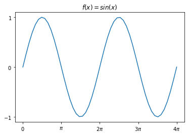

```python
plot_sinx(x, f)
```

## Why data visualization: using as a tool that addresses the gap between function, formula and viewers

$$S(x) = \frac{1}{1 + e^{-x}}$$

## Gap addressed: function, formula and viewers

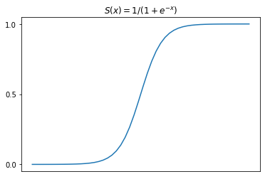

```python
plot_sigmoid(x, S)
```

## Visualization also plays a key role in machine learning

## Machine learning engineer uses line plot to visualize cost function

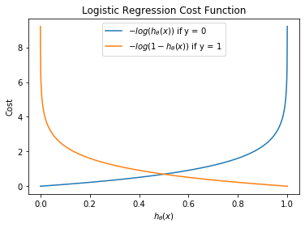

```python
plot_logistic_cost_function(x)
```

## Machine learning engineer uses surface plot or contour plot to visualize gradients

[figure not shown]

Source: [Coursera | Machine Learning](https://www.coursera.org/learn/machine-learning)

## Machine learning engineer also uses contour plot to visualize gradients

[figure not shown]

Source: [Coursera | Machine Learning](https://www.coursera.org/learn/machine-learning)

## Machine learning engineer uses scatter plot and contour plot to visualize decision boundary

Source: https://scikit-learn.org/stable/auto_examples/ensemble/plot_voting_decision_regions.html#sphx-glr-auto-examples-ensemble-plot-voting-decision-regions-py

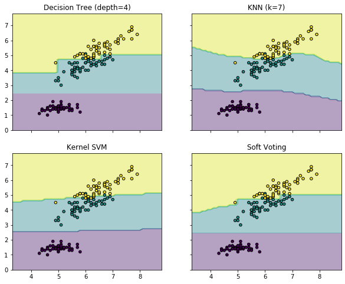

```python
plot_multiple_decision_boundary()
```

## The 2 most influential visualizations of ALL TIME

1. [Minard's map of Napoleon's disastrous Russian campaign of 1812](https://en.wikipedia.org/wiki/Flow_map#/media/File:Minard.png)
2. [Hans Rosling's 200 Countries, 200 Years, 4 Minutes](https://youtu.be/jbkSRLYSojo)

## [Minard's map of Napoleon's disastrous Russian campaign of 1812](https://en.wikipedia.org/wiki/Flow_map#/media/File:Minard.png)

In 1812, Napoleon marched to Moscow. 98% of his soldiers died. The simple but fascinating temperature line below the viz shows how cold ultimately defeated Napoleon’s army.

[figure not shown]

## [Hans Rosling's 200 Countries, 200 Years, 4 Minutes](https://youtu.be/jbkSRLYSojo)

A 2007 TED talk for the Swedish scientist shared his passion with the world. It shows the relationship between wealth and health.

[figure not shown]

## A quick look back to the data science pipeline

[figure not shown]

Source: [R for Data Science](https://r4ds.had.co.nz/)

## Visualization plays heavy roles in

- Visualization
- Modeling
- Communicattion

## Popular libraries we can use in Python for visualization

- `pandas`
- `seaborn`
- `matplotlib`
- `plotly`

## Difference between these libraries

- Plotting with `DataFrame` or `Series`
  - `pandas`
  - `seaborn`
- Plotting with `list`, `ndarray`, or `Series`
  - `matplotlib`
- Plotting with interactivity
  - `plotly`

## Importing these libraries

```python
import pandas as pd
import seaborn as sns
import matplotlib.pyplot as plt
```

## Getting data for a quickstart on these libraries

```python
order_slave_dtypes = {
    'PaymentType': 'str',
    'ShippingType': 'str'
}
behavior_dtypes = {
    'CategoryId': 'str',
    'SearchKeyWord': 'str',
    'TransactionNum': 'str'
}
member = pd.read_csv('MemberDataForNTU.csv')
order_main = pd.read_csv('OrderDataForNTU.csv')
order_slave = pd.read_csv('OrderSlaveDataForNTU.txt', dtype=order_slave_dtypes)
behavior = pd.read_csv('BehaviorDataForNTU.csv', dtype=behavior_dtypes)
```

## Choose appropriate plots according to analytical purposes

- Bar for ranking and comparison
- Scatter for correlation
- Histogram for distribution
- Line for trend
- Box for distribution across different categories

## How to plot with `pandas`

`DataFrame` class has a `.plot()` method with several key parameters.

## Make a groupby summary with `pandas`

```python
order_main.groupby('PaymentType')['TotalSalesAmount'].sum().sort_values()
```

```
PaymentType
ATM                    91308
LinePay              6214910
Family              75396620
CreditCardOnce      80850669
SevenEleven         86959405
Cash              1093109830
Name: TotalSalesAmount, dtype: int64
```

## Make a barh with `pandas` following groupby summary

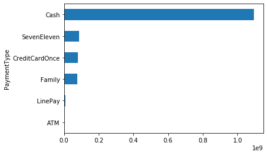

```python
sale_amount_by_payment_type = order_main.groupby('PaymentType')['TotalSalesAmount'].sum().sort_values()
sale_amount_by_payment_type.plot(kind='barh')
plt.show()
```

## Make another groupby summary with `pandas`

```python
order_main['TradesDate'] = pd.to_datetime(order_main['TradesDate'])
order_main.groupby('TradesDate')['TotalSalesAmount'].sum()
```

```
TradesDate
2016-01-01     920950
2016-01-02     966747
2016-01-03     704524
2016-01-04     660950
2016-01-05     717040
               ...
2019-04-27    1575247
2019-04-28    1285845
2019-04-29    1292115
2019-04-30    2225314
2019-05-01      26440
Name: TotalSalesAmount, Length: 1217, dtype: int64
```

## Make a line with pandas following groupby summary

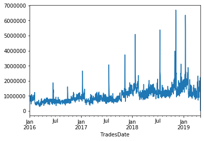

```python
sale_amount_by_trades_date = order_main.groupby('TradesDate')['TotalSalesAmount'].sum()
sale_amount_by_trades_date.plot(kind='line')
plt.show()
```

## How to plot with `seaborn`

Using different plotting functions

- `barplot` function for a bar
- `lineplot` function for a line

## Transform groupby summary to a `DataFrame` with `pandas`

```python
sale_amount_by_payment_type_df = pd.DataFrame(sale_amount_by_payment_type).reset_index().sort_values('TotalSalesAmount', ascending=False)
sale_amount_by_payment_type_df
```

|  | PaymentType | TotalSalesAmount |
| --- | --- | --- |
| 5 | Cash | 1093109830 |
| 4 | SevenEleven | 86959405 |
| 3 | CreditCardOnce | 80850669 |
| 2 | Family | 75396620 |
| 1 | LinePay | 6214910 |
| 0 | ATM | 91308 |

## `barplot` function for a bar

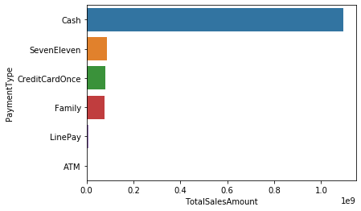

```python
sns.barplot(x='TotalSalesAmount', y='PaymentType', data=sale_amount_by_payment_type_df)
plt.show()
```

## Transform groupby summary to another `DataFrame` with `pandas`

```python
sale_amount_by_trades_date_shipping_type = order_main.groupby(['TradesDate', 'ShippingType'])['TotalSalesAmount'].sum()
sale_amount_by_trades_date_shipping_type_df = pd.DataFrame(sale_amount_by_trades_date_shipping_type).reset_index()
sale_amount_by_trades_date_shipping_type_df
```

|  | TradesDate | ShippingType | TotalSalesAmount |
| --- | --- | --- | --- |
| 0 | 2016-01-01 | Family | 3740 |
| 1 | 2016-01-01 | Home | 18370 |
| 2 | 2016-01-01 | SevenEleven | 18780 |
| 3 | 2016-01-01 | Store | 880060 |
| 4 | 2016-01-02 | Family | 18260 |
| ... | ... | ... | ... |
| 7147 | 2019-04-30 | Store | 1682940 |
| 7148 | 2019-05-01 | Family | 4830 |
| 7149 | 2019-05-01 | Home | 16680 |
| 7150 | 2019-05-01 | LocationPickup | 2660 |
| 7151 | 2019-05-01 | SevenEleven | 2270 |

7152 rows × 3 columns

## `lineplot` function for a line

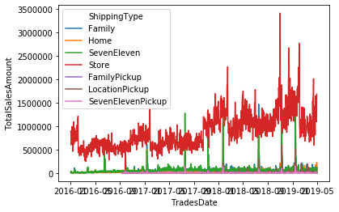

```python
sns.lineplot(x='TradesDate', y='TotalSalesAmount', hue='ShippingType', data=sale_amount_by_trades_date_shipping_type_df)
plt.show()
```

## How to plot with `matplotlib`

- Arranging data to iterables: `list`, `ndarray` or `Series`
- Call `figure` function for a "figure" object
- Call `axes` function for an "axis" object
- Call plotting methods from an axis object
- Add elements
- Call `show` function for display

## Take a bar for example: figure and axes first

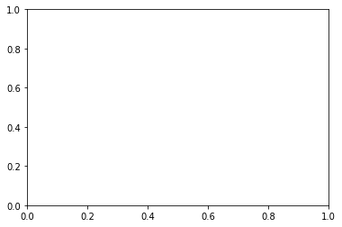

```python
fig = plt.figure()
axes = plt.axes()
```

## Take a bar for example: call plotting methods and show plot

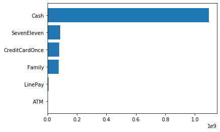

```python
fig = plt.figure()
axes = plt.axes()
axes.barh(sale_amount_by_payment_type.index, sale_amount_by_payment_type.values)
plt.show()
```

## Take a line for another example: figure and axes first

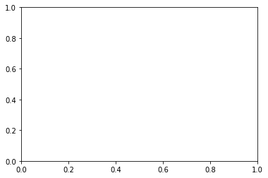

```python
fig = plt.figure()
axes = plt.axes()
```

## Take a line for another example: call plotting methods and show plot

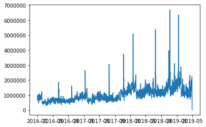

```python
fig = plt.figure()
axes = plt.axes()
x = sale_amount_by_trades_date.index
y = sale_amount_by_trades_date.values
axes.plot(x, y)
plt.show()
```

## The line seems a bit too narrow for us...maybe it's time to add interactivity on it

```python
import plotly.graph_objs as go
```

```python
# Create df
df = pd.DataFrame(sale_amount_by_trades_date).reset_index()
# Create figure
layout = go.Layout(
    autosize=False,
    width=720,
    height=480,
    margin=go.layout.Margin(
        l=50,
        r=50,
        b=100,
        t=100,
        pad=4
    ),
    bargroupgap=0.3
)
fig = go.Figure(layout=layout)
```

```python
fig.add_trace(
    go.Scatter(x=list(df.TradesDate), y=list(df.TotalSalesAmount)))
# Set title
fig.update_layout(
    title_text="Time series with range slider and selectors"
)
```

[interactive chart not shown]

```python
# Add range slider
fig.update_layout(
    xaxis=dict(
        rangeselector=dict(
            buttons=list([
                dict(count=1,
                     label="1m",
                     step="month",
                     stepmode="backward"),
                dict(count=6,
                     label="6m",
                     step="month",
                     stepmode="backward"),
                dict(count=1,
                     label="YTD",
                     step="year",
                     stepmode="todate"),
                dict(count=1,
                     label="1y",
                     step="year",
                     stepmode="backward"),
                dict(step="all")
            ])
        ),
        rangeslider=dict(
            visible=True
        ),
        type="date"
    )
)
fig.show()
```

[interactive chart not shown]

## Plotting is all about documentation!

- [Pandas visualization](https://pandas.pydata.org/pandas-docs/stable/user_guide/visualization.html)
- [Seaborn API Reference](https://seaborn.pydata.org/api.html)
- [Matplotlib documentation](https://matplotlib.org/index.html)
- [Plotly documentation](https://plotly.com/python/)